# Part I - (Used car dataset exploration)

## Introduction

The `user car dataset` is a large dataset gathered by a consulting firm across the market through their market survey

#### Dataset Dictionary

- **sales_id:** the recorded sales id
- **name:** the name of the car/ the car company name -**year:** the year of purchase -**selling_price:** the selling price of the car -**km_driven:** the distance driven by the car in kilometers -**region:** the region the car is used -**state:** the state the car is used -**city:** the city where the car is used -**fuel:** the type of fuel used by the car -**seller_type:** who sells the car -**transmission:** the transmission type of the car -**owner:** the type of ownership -**mileage:** the distance travelled per gasoline/fuel used -**engine** the engine size in cubic centimeter(cc) -**max_power:** the power/horsepower of the car -**torque:** the turning force capacity in Newton meter(Nm) -**max_rpm:** the highest revolution per minute(rpm) -**seats :** the number of seats in the car -**sold:** the state of car, sold or not

## Preliminary Wrangling

```python
# import all packages and set plots to be embedded inline
import numpy as np
import pandas as pd
import matplotlib.pyplot as plt
import seaborn as sns

%matplotlib inline
```

```python
#loading the dataset into a pandas DataFrame
car2 = pd.read_csv('UserCarData2.csv')
```

```python
#duplication of the dataset
car = car2.copy()
```

```python
#showing first few rows of the dataset
car.head()
```

|  | sales_id | name | year | selling_price | km_driven | region | state | city | fuel | seller_type | transmission | owner | mileage | engine | max_power | torque | max_rpm | seats | sold |
| --- | --- | --- | --- | --- | --- | --- | --- | --- | --- | --- | --- | --- | --- | --- | --- | --- | --- | --- | --- |
| 0 | 1 | Maruti | 2014 | 450000 | 145500 | East | District of Columbia | Washington | Diesel | Individual | Manual | First_Owner | 23.40 | 1248 | 74.00 | 190.0 | 2000.0 | 5 | Y |
| 1 | 2 | Skoda | 2014 | 370000 | 120000 | East | New York | New York City | Diesel | Individual | Manual | Second_Owner | 21.14 | 1498 | 103.52 | 250.0 | 2500.0 | 5 | Y |
| 2 | 3 | Honda | 2006 | 158000 | 140000 | Central | Illinois | Chicago | Petrol | Individual | Manual | Third_Owner | 17.70 | 1497 | 78.00 | 12.7 | 2700.0 | 5 | Y |
| 3 | 4 | Hyundai | 2010 | 225000 | 127000 | Central | Illinois | Chicago | Diesel | Individual | Manual | First_Owner | 23.00 | 1396 | 90.00 | NaN | NaN | 5 | Y |
| 4 | 5 | Maruti | 2007 | 130000 | 120000 | East | New York | New York City | Petrol | Individual | Manual | First_Owner | 16.10 | 1298 | 88.20 | 11.5 | 4500.0 | 5 | Y |

```python
#general info
car.info();
```

```
<class 'pandas.core.frame.DataFrame'>
RangeIndex: 7906 entries, 0 to 7905
Data columns (total 19 columns):
 #   Column         Non-Null Count  Dtype
---  ------         --------------  -----
 0   sales_id       7906 non-null   int64
 1   name           7906 non-null   object
 2   year           7906 non-null   int64
 3   selling_price  7906 non-null   int64
 4   km_driven      7906 non-null   int64
 5   region         7906 non-null   object
 6   state          7906 non-null   object
 7   city           7906 non-null   object
 8   fuel           7906 non-null   object
 9   seller_type    7906 non-null   object
 10  transmission   7906 non-null   object
 11  owner          7906 non-null   object
 12  mileage        7906 non-null   float64
 13  engine         7906 non-null   int64
 14  max_power      7906 non-null   float64
 15  torque         7641 non-null   object
 16  max_rpm        7641 non-null   float64
 17  seats          7906 non-null   int64
 18  sold           7906 non-null   object
dtypes: float64(3), int64(6), object(10)
memory usage: 1.1+ MB
```

```python
#general statistics
car.describe()
```

|  | sales_id | year | selling_price | km_driven | mileage | engine | max_power | max_rpm | seats |
| --- | --- | --- | --- | --- | --- | --- | --- | --- | --- |
| count | 7906.000000 | 7906.000000 | 7.906000e+03 | 7.906000e+03 | 7906.000000 | 7906.000000 | 7906.000000 | 7641.000000 | 7906.000000 |
| mean | 4070.106248 | 2013.983936 | 6.498137e+05 | 6.918866e+04 | 19.419861 | 1458.708829 | 91.587374 | 3086.384766 | 5.416393 |
| std | 2345.770159 | 3.863695 | 8.135827e+05 | 5.679230e+04 | 4.036263 | 503.893057 | 35.747216 | 929.916683 | 0.959208 |
| min | 1.000000 | 1994.000000 | 2.999900e+04 | 1.000000e+00 | 0.000000 | 624.000000 | 32.800000 | 500.000000 | 2.000000 |
| 25% | 2037.250000 | 2012.000000 | 2.700000e+05 | 3.500000e+04 | 16.780000 | 1197.000000 | 68.050000 | 2400.000000 | 5.000000 |
| 50% | 4076.500000 | 2015.000000 | 4.500000e+05 | 6.000000e+04 | 19.300000 | 1248.000000 | 82.000000 | 3000.000000 | 5.000000 |
| 75% | 6102.000000 | 2017.000000 | 6.900000e+05 | 9.542500e+04 | 22.320000 | 1582.000000 | 102.000000 | 4000.000000 | 5.000000 |
| max | 8128.000000 | 2020.000000 | 1.000000e+07 | 2.360457e+06 | 42.000000 | 3604.000000 | 400.000000 | 21800.000000 | 14.000000 |

### Visual assessment

1. Minimum `mileage` is 0
2. `Seats` columns has an integer type datapoints
3. `Sold` column has `Y` and `N` data points
4. There are `null values`
5. The `kilometer driven` column looks like it's in `meters`

### Programmatic assessment

```python
#checking for duplicate values
car.duplicated().any()
```

```
False
```

```python
#checking for any null values
print(car.isna().any().sum())
car.isna().any()
```

```
2
```

```
sales_id         False
name             False
year             False
selling_price    False
km_driven        False
region           False
state            False
city             False
fuel             False
seller_type      False
transmission     False
owner            False
mileage          False
engine           False
max_power        False
torque            True
max_rpm           True
seats            False
sold             False
dtype: bool
```

```python
#more on the null values
car.isna().sum()
```

```
sales_id           0
name               0
year               0
selling_price      0
km_driven          0
region             0
state              0
city               0
fuel               0
seller_type        0
transmission       0
owner              0
mileage            0
engine             0
max_power          0
torque           265
max_rpm          265
seats              0
sold               0
dtype: int64
```

```python
#defining a function that will take the value counts for all categorical variables owner

def val_cnts():
    val_cnt1 = car['owner'].value_counts() #value count for owner
    val_cnt2 = car['transmission'].value_counts() #value count for transmission
    val_cnt3 = car['seller_type'].value_counts() #value count for seller_type
    val_cnt4 = car['fuel'].value_counts()#value count for fuel
    val_cnt5 = car['region'].value_counts() #value count for region
    val_cnt6 = car['sold'].value_counts()#value count for  sold
    val_cnt7 = car['seats'].value_counts()#value count for seats

    print(val_cnt1)
    print(val_cnt2)
    print(val_cnt3)
    print(val_cnt4)
    print(val_cnt5)
    print(val_cnt6)
    print(val_cnt7)
```

```python
#taking the unique value counts
val_cnts()
```

```
First_Owner           5215
Second_Owner          2016
Third_Owner            510
Fourth_Above_Owner     160
Test_Drive_Car           5
Name: owner, dtype: int64
Manual       6865
Automatic    1041
Name: transmission, dtype: int64
Individual          6563
Dealer              1107
Trustmark_Dealer     236
Name: seller_type, dtype: int64
Diesel    4299
Petrol    3520
CNG         52
LPG         35
Name: fuel, dtype: int64
Central    2376
West       1976
East       1939
South      1615
Name: region, dtype: int64
N    5906
Y    2000
Name: sold, dtype: int64
5     6254
7     1120
8      235
4      133
9       80
6       62
10      19
2        2
14       1
Name: seats, dtype: int64
```

```python
#checking for the counts of the year appearances
car['year'].value_counts()
```

```
2017    1010
2016     856
2018     806
2015     775
2013     668
2012     621
2014     620
2019     583
2011     570
2010     375
2009     231
2008     201
2007     173
2006     102
2005      76
2020      74
2004      51
2003      37
2002      19
2000      15
1999      14
1998       9
1997       9
2001       6
1994       2
1996       2
1995       1
Name: year, dtype: int64
```

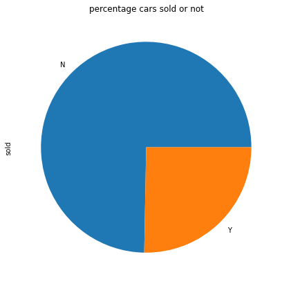

```python
#percentage of cars sold and not sold with graphical demostration
percent = car['sold'].value_counts()/7639*100
percent.plot(kind = 'pie',figsize=(12,7))
plt.title('percentage cars sold or not');
```

```python
#total value of price of cars
print('sum of the car prices is ''$' + str(car['selling_price'].sum()/1e9)+'bn')

#mean price of cars
print('average price of cars is '+'$' + str(car['selling_price'].mean()/1e3)+'k')

#minimum price
print('minimum price of cars is '+'$' + str(car['selling_price'].min()/1e3)+'k')

#maximum price
print('maximum price of cars is '+'$' + str(car['selling_price'].max()/1e6)+'bn')
```

[output not shown]

```python
#checking total price of cars either sold or not(in billions dollars)
car['selling_price'].sum()
tot_val = car.groupby('sold').sum().selling_price/1e9
tot_val
```

```
sold
N    3.784684
Y    1.352743
Name: selling_price, dtype: float64
```

```python
#mean price for the cars in the dataset (in thousand dollars)
ave_val = car.groupby('sold').mean().selling_price/1000
ave_val
```

```
sold
N    640.820217
Y    676.371538
Name: selling_price, dtype: float64
```

### Cleaning

```python
#substituting the CNG and LPG abbreviations in the fuel column with their Acronymns
car['fuel'].replace('CNG','compressed natural gas', inplace=True)
car['fuel'].replace('LPG','liquified petroleum gas', inplace=True)
```

```python
#checking for effected changes
car['fuel'].value_counts()
```

```
Diesel                     4299
Petrol                     3520
compressed natural gas       52
liquified petroleum gas      35
Name: fuel, dtype: int64
```

```python
#dropping the rows with the null values
car.dropna( inplace = True)
```

```python
#testing for effected changes
car.isna().any().sum()
```

```
0
```

```python
#sunstituting the Y with yes and N with No in the sold column
car['sold'].replace('Y','Yes',inplace=True)
car['sold'].replace('N','No',inplace=True)
```

```python
#checking for effected change
car.sold.value_counts()
```

```
No     5725
Yes    1916
Name: sold, dtype: int64
```

```python
#examing the unique values of the seat columns
car.seats.unique()
```

```
array([ 5,  4,  7,  8,  6,  9, 10, 14,  2], dtype=int64)
```

```python
#replacing the numerics in the seat columns with strings/spellings
car['seats'].replace([ 2,4,5,6,7,8,9,10,14],
                     ['two','four','five','six','seven','eight','nine','ten','fourteen'],inplace = True)
```

```python
#ckecking for effected changes
car.seats.unique()
```

```
array(['five', 'four', 'seven', 'eight', 'six', 'nine', 'ten', 'fourteen',
       'two'], dtype=object)
```

```python
#converting the torque column to float
car.torque = pd.to_numeric(car.torque, errors='coerce').convert_dtypes()
#checking for change
car.torque.dtype
```

```
Float64Dtype()
```

```python
#changing the following columns datatype to integer
#year, selling_price, year, engine, max_rpm, max_power

def D_var(a):
    car[a].astype('int64')
```

```python
#making the changes for each
D_var('selling_price')
D_var('engine')
D_var('max_rpm')
D_var('year')
D_var('max_power')
```

```python
#checking for effected changes
car.info()
```

```
<class 'pandas.core.frame.DataFrame'>
Int64Index: 7641 entries, 0 to 7905
Data columns (total 19 columns):
 #   Column         Non-Null Count  Dtype
---  ------         --------------  -----
 0   sales_id       7641 non-null   int64
 1   name           7641 non-null   object
 2   year           7641 non-null   int64
 3   selling_price  7641 non-null   int64
 4   km_driven      7641 non-null   int64
 5   region         7641 non-null   object
 6   state          7641 non-null   object
 7   city           7641 non-null   object
 8   fuel           7641 non-null   object
 9   seller_type    7641 non-null   object
 10  transmission   7641 non-null   object
 11  owner          7641 non-null   object
 12  mileage        7641 non-null   float64
 13  engine         7641 non-null   int64
 14  max_power      7641 non-null   float64
 15  torque         7639 non-null   Float64
 16  max_rpm        7641 non-null   float64
 17  seats          7641 non-null   object
 18  sold           7641 non-null   object
dtypes: Float64(1), float64(3), int64(5), object(10)
memory usage: 1.2+ MB
```

```python
#dividing the km_driven column by 1000 to convert it to Km
car['km_driven'] = car['km_driven']/1000
```

```python
#checking for effected changes
car['km_driven'].sample(5)
```

```
190       5.000
250     158.000
1301     33.033
6409      2.000
4963     70.000
Name: km_driven, dtype: float64
```

### What is/are the main feature(s) of interest in your dataset?

> the main feature of interest in this dataset are year of purchase, selling price or car worth and whether the cars have been sold or not.

### What features in the dataset do you think will help support your investigation into your feature(s) of interest?

> The key features that can support this investigation would be the non-mechanical properties of cars such as seats number, region, name, and mechanical features like mileage, engine, max_power, torque, max_rpm etc

## Univariate Exploration

#### What is the general distribution in the numeric features of the datasets?

#### Visualization

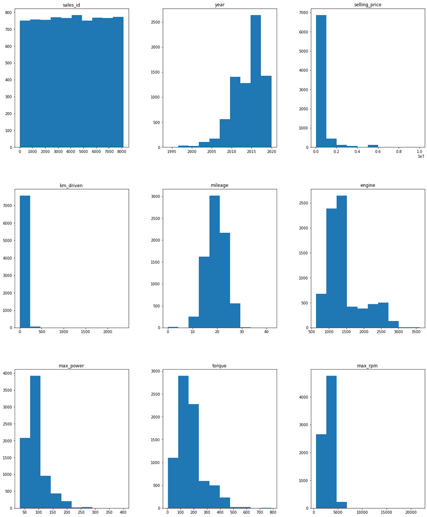

```python
#what is the various distribution of the different numeric variables
car.hist(figsize = (20, 25),bins=10, grid=False);
```

#### Observation

The features will be explored individually for a closer look at the distribution

#### Question:

What is the distribution in selling_price?

#### Visualization

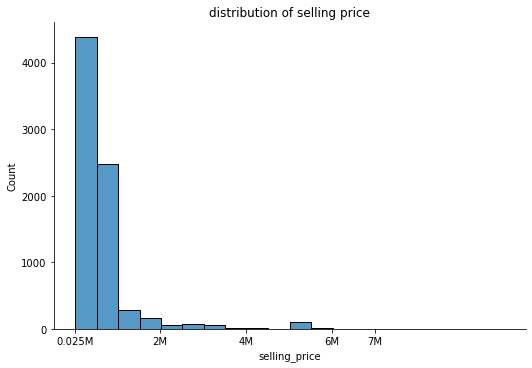

```python
#plotting the distribution for selling price
sns.displot(car, x='selling_price', bins=20, aspect =1.5)
plt.xticks([25e3,2000e3,4000e3,6000e3,7000e3],['0.025M','2M','4M','6M','7M'])
plt.title('distribution of selling price');
```

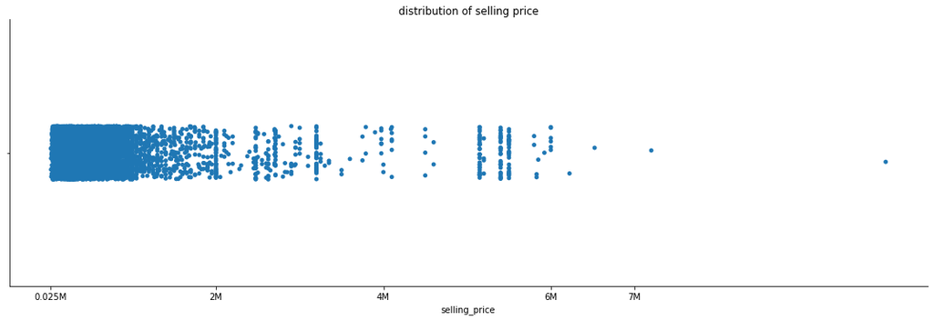

```python
#using scatter plot to get a complemetary view of this distrubtion
sns.catplot(data = car, x='selling_price', aspect = 3)
plt.xticks([25e3,2000e3,4000e3,6000e3,7000e3],['0.025M','2M','4M','6M','7M'])
plt.title('distribution of selling price');
```

```python
#creating a function that will provide the limits
def limit_finder(df):
    Q1 = df.quantile(0.25)
    Q3 = df.quantile(0.75)
    inter_quautile_range = IQR = Q3-Q1
    lower_limit_boundary = llb = Q1 - (IQR*1.5)
    upper_limit_boundary = ulb = Q3 + (IQR*1.5)
    print('this is lower boundary :',llb)
    print('this is upper boundary :', ulb)
    print('this is mean :', df.mean())
```

```python
#finding the limits and mean in the selling price column
limit_finder(car.selling_price)
```

```
this is lower boundary : -375000.0
this is upper boundary : 1345000.0
this is mean : 645911.1745844785
```

```python
#assessing the values above the upper limit
car.query('selling_price > 1342000.0')
```

|  | sales_id | name | year | selling_price | km_driven | region | state | city | fuel | seller_type | transmission | owner | mileage | engine | max_power | torque | max_rpm | seats | sold |
| --- | --- | --- | --- | --- | --- | --- | --- | --- | --- | --- | --- | --- | --- | --- | --- | --- | --- | --- | --- |
| 39 | 42 | Jeep | 2019 | 2100000 | 5.000 | East | New York | New York City | Petrol | Individual | Automatic | First_Owner | 16.00 | 1368 | 160.77 | 250.0 | 2500.0 | five | Yes |
| 45 | 48 | Toyota | 2014 | 1500000 | 77.000 | West | Washington | Seattle | Diesel | Dealer | Manual | First_Owner | 12.55 | 2982 | 168.50 | 343.0 | 3400.0 | seven | Yes |
| 47 | 50 | Mercedes | 2014 | 1450000 | 27.800 | East | New York | New York City | Diesel | Dealer | Automatic | Second_Owner | 14.80 | 2143 | 120.70 | 200.0 | 4000.0 | five | Yes |
| 53 | 56 | Toyota | 2016 | 1650000 | 127.700 | East | Massachusetts | Boston | Diesel | Dealer | Automatic | Second_Owner | 11.36 | 2755 | 171.50 | 360.0 | 3400.0 | seven | Yes |
| 55 | 58 | Audi | 2013 | 1750000 | 33.900 | South | Georgia | Atlanta | Diesel | Dealer | Automatic | Second_Owner | 17.68 | 1968 | 174.33 | 380.0 | 2500.0 | five | Yes |
| ... | ... | ... | ... | ... | ... | ... | ... | ... | ... | ... | ... | ... | ... | ... | ... | ... | ... | ... | ... |
| 7731 | 7950 | Toyota | 2015 | 1400000 | 170.000 | East | New York | East Massapequa | Diesel | Individual | Manual | First_Owner | 12.99 | 2494 | 100.60 | 200.0 | 3400.0 | seven | No |
| 7749 | 7968 | BMW | 2011 | 1500000 | 84.925 | West | Nevada | Reno | Diesel | Individual | Automatic | First_Owner | 16.07 | 1995 | 181.00 | 380.0 | 3000.0 | five | No |
| 7755 | 7974 | Toyota | 2015 | 1400000 | 170.000 | East | Ohio | Columbus | Diesel | Individual | Manual | First_Owner | 12.99 | 2494 | 100.60 | 200.0 | 3400.0 | seven | No |
| 7838 | 8059 | Audi | 2017 | 1689999 | 8.000 | South | Arkansas | Van Buren | Petrol | Dealer | Automatic | First_Owner | 16.60 | 1798 | 177.50 | 250.0 | 5000.0 | five | No |
| 7886 | 8109 | Kia | 2019 | 1575000 | 20.000 | West | California | Laguna Hills | Diesel | Individual | Automatic | First_Owner | 17.80 | 1493 | 113.40 | 250.0 | 2750.0 | five | No |

559 rows × 19 columns

#### Question

The distribution of the Revolution Per Meter

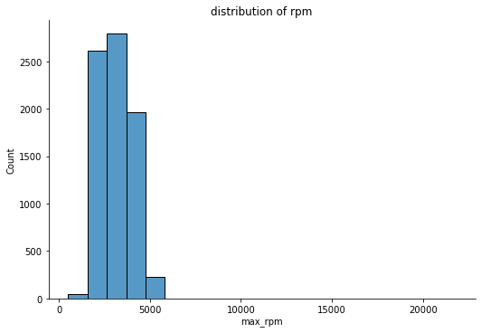

```python
##plotting the distribution for rpm
sns.displot(car, x='max_rpm', bins=20, aspect=1.5)
plt.title('distribution of rpm');
```

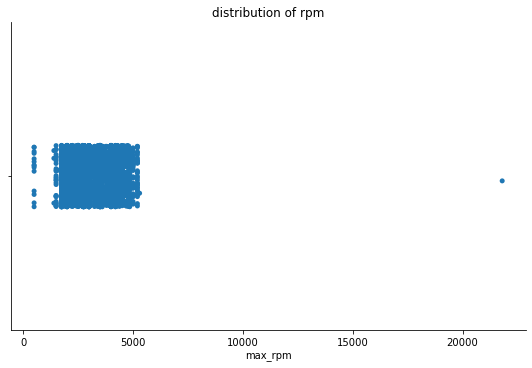

```python
#using scatter plot to get a complemetary view of this distrubtion
sns.catplot(data = car, x='max_rpm', aspect=1.5)
plt.title('distribution of rpm');
```

```python
#finding the limits and mean in the rpm column
limit_finder(car.max_rpm)
```

```
this is lower boundary : 0.0
this is upper boundary : 6400.0
this is mean : 3086.3847663918336
```

```python
#assessing the limits above the upper bound
car.query('max_rpm > 6400.0')
```

|  | sales_id | name | year | selling_price | km_driven | region | state | city | fuel | seller_type | transmission | owner | mileage | engine | max_power | torque | max_rpm | seats | sold |
| --- | --- | --- | --- | --- | --- | --- | --- | --- | --- | --- | --- | --- | --- | --- | --- | --- | --- | --- | --- |
| 5265 | 5416 | Tata | 2005 | 225000 | 188.0 | West | Washington | Lynnwood | Diesel | Individual | Manual | First_Owner | 12.3 | 1948 | 90.0 | 190.0 | 21800.0 | seven | No |

```python
#deleting values above rpm of 6250 rpm
car = car.query('max_rpm < 6250.0')
```

#### Observation

The distribution plot indicate the potential presence of outlier(s)

#### Question

what is the distribution of the mileage

#### Visualization

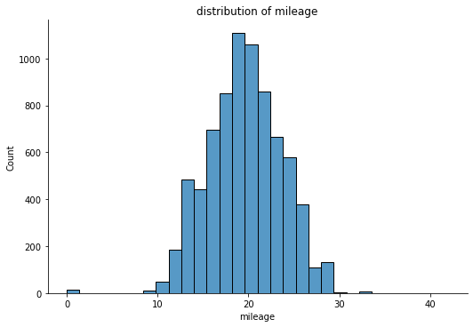

```python
#plotting the distribution of mileage
sns.displot(car, x='mileage', bins=30, aspect= 1.5)
plt.title('distribution of mileage');
```

```python
#finding the limits and mean in the mileage column
limit_finder(car.mileage)
```

```
this is lower boundary : 8.520000000000001
this is upper boundary : 30.6
this is mean : 19.507554973821975
```

```python
#sum of values above the limit and below the limit
car.query('mileage >30 | mileage < 8').count()['mileage']
```

```
25
```

```python
#making the mileage columns stay within the limit values
car = car.query('mileage <30 ')
car = car.query(' mileage > 8')
```

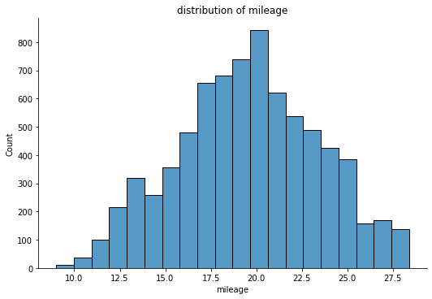

```python
#getting the new distribution plotting
sns.displot(car, x='mileage', bins=20, aspect= 1.5)
plt.title('distribution of mileage');
```

#### Observation

The distribution is normal, however potential outliers exist as the distribution goes down to somewhere around `0` which is abnormal.

further programmatic assessment has been done above.

> The distribution looks normal after removing the outliers

#### Question

The distribution of the torque column

#### Visualization

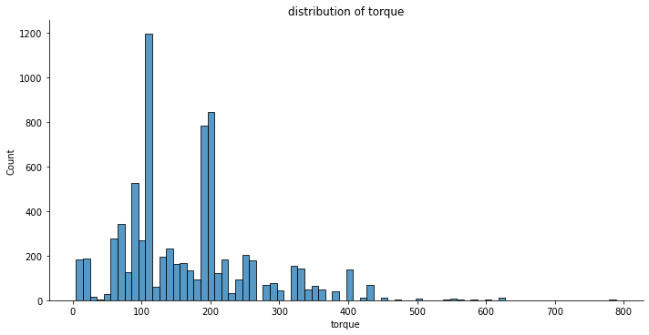

```python
#distribution plotting for torque
sns.displot(car, x = 'torque', aspect = 2)
plt.title('distribution of torque');
```

#### Observation

The distribution is not skewed properly. The highs are around the `100` and `200` torque value in `Nm`.

#### Question

What's the yearly distribution

#### Visualization

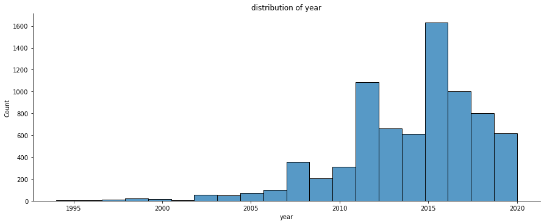

```python
#plotting the distribution of year
sns.displot(car, x='year', bins=20,aspect = 2.5)
plt.title('distribution of year');
```

#### Observation

Distribution is skewed to the left with more cars purchased recently between `2010` and `2020`

#### Question

What's the distribution on the `max_power` column

#### Visualization

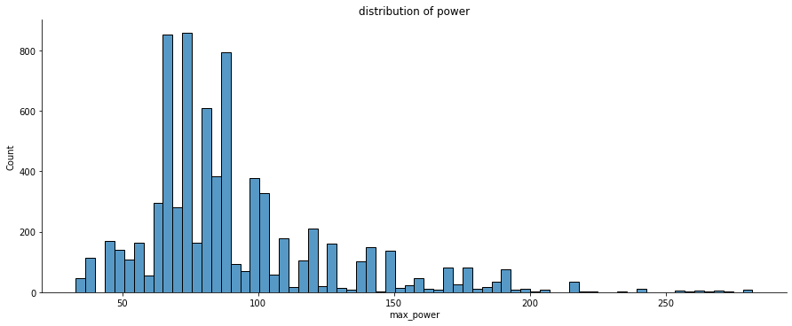

```python
#plotting the distribution of power
sns.displot(car, x='max_power', bins=70,aspect = 2.5)
plt.title('distribution of power');
```

#### Question

What's the engine size distribution

#### Visualization

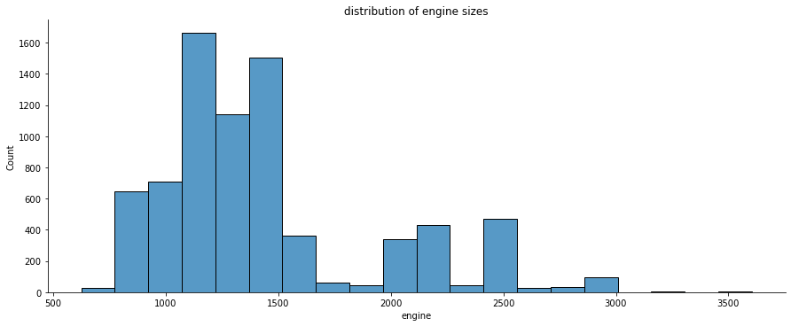

```python
#plotting the distribution of the engine size
sns.displot(car, x='engine', bins=20,aspect = 2.5)
plt.title('distribution of engine sizes');
```

#### Observation

distribution is not properly skewed. Most cars have engine sizes between 500 and 2000 cc

#### Question

What is the distrution of the kilometer driven

#### Visualization

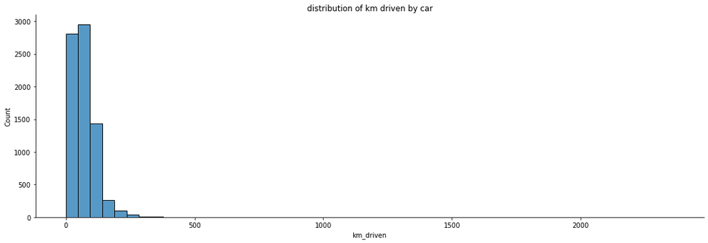

```python
#distribution of km driven by cars
sns.displot(data = car, x='km_driven', aspect = 3, bins=50)
plt.title('distribution of km driven by car');
```

#### Observation

The distributio is well skewed to the right, however the range between `500` and `2000` is wide and suppose to conform to the `Km` unit. Scatterplot is used below to show whether this could be identified as outliers

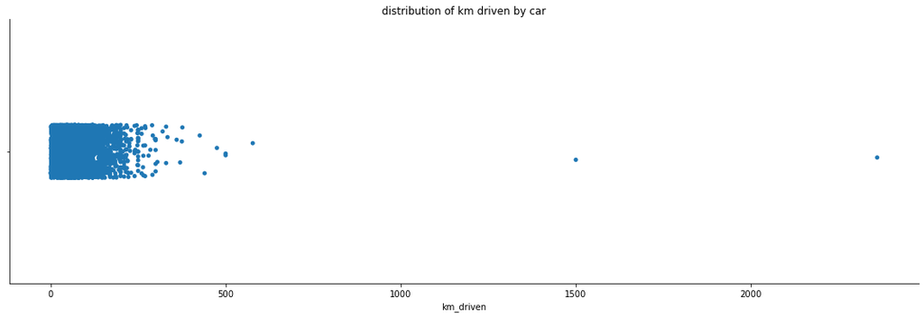

```python
#using scatter plot to get a complemetary view of this distrubtion
sns.catplot(data = car, x='km_driven', aspect = 3)
plt.title('distribution of km driven by car');
```

```python
#using an already defined funtion to locate the limits and mean of the km driven
limit_finder(car.km_driven)
```

```
this is lower boundary : -52.53
this is upper boundary : 175.638
this is mean : 68.22745160866693
```

```python
#keeping the values of the kilometer driven within the lower limit
car = car.query('km_driven < 177')
```

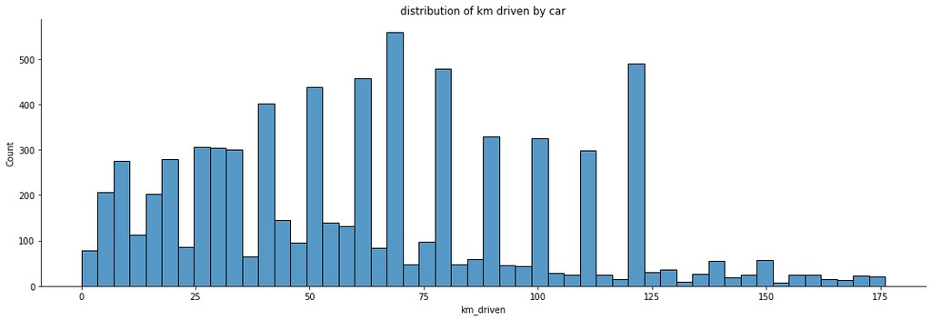

```python
#distribution of km driven by cars after removing outliers
sns.displot(data = car, x='km_driven', aspect = 3, bins=50)
plt.title('distribution of km driven by car');
```

### NON-NUMERIC/CATEGORICAL VARIABLES

#### Visualization

```python
#defining a function that will plot all non-numeric variable distributions
def cat_plt(a):
    print('Title : distribution of ' + a)
    sns.catplot(data = car, x=a,kind='count',aspect  = 2)
    plt.show();
```

```
Title : distribution of region
```

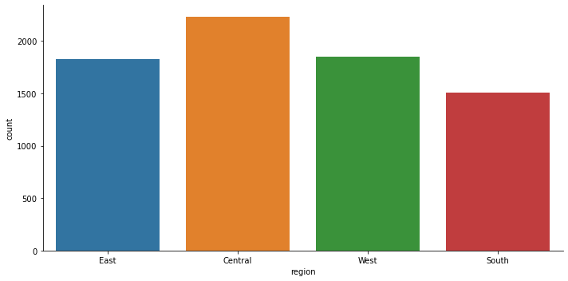

```
Title : distribution of owner
```

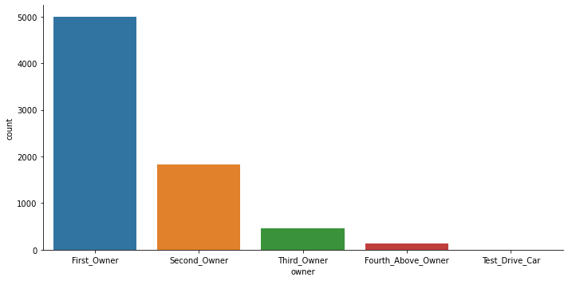

```
Title : distribution of seller_type
```

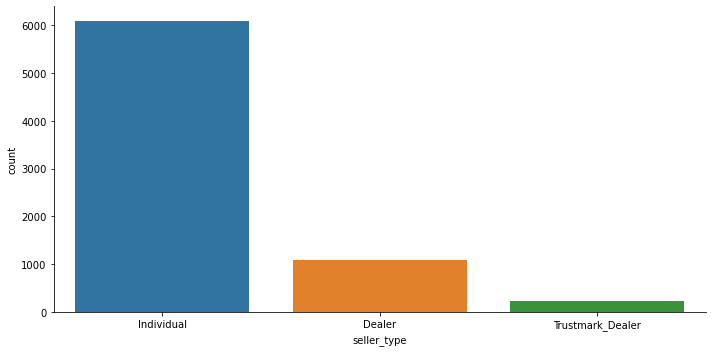

```
Title : distribution of transmission
```

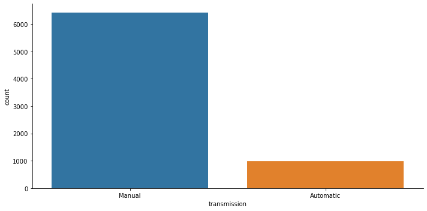

```
Title : distribution of fuel
```

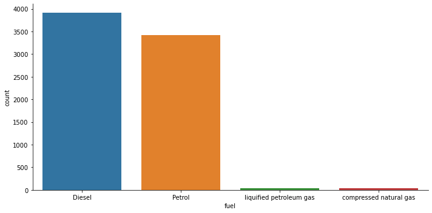

```
Title : distribution of seats
```

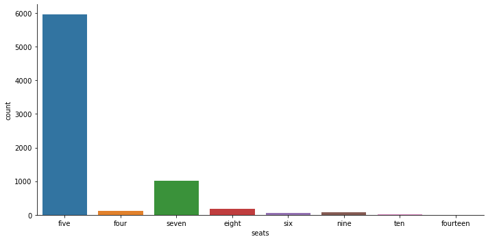

```
Title : distribution of sold
```

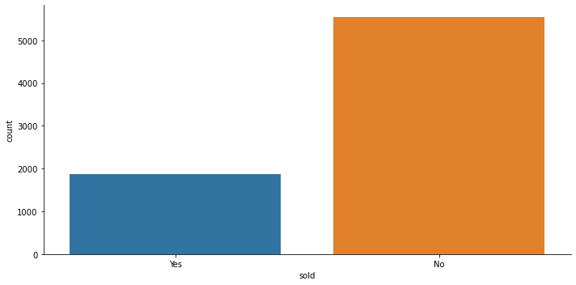

```python
#applying the formular to all non-numeric/categorical variable

#plotting for region
cat_plt('region')
# plotting for owner
cat_plt('owner')
# plotting for seller_type
cat_plt('seller_type')
# plotting for transmission
cat_plt('transmission')
# plotting for fuel
cat_plt('fuel')
# plotting for seats
cat_plt('seats')
# plotting for sold
cat_plt('sold')
```

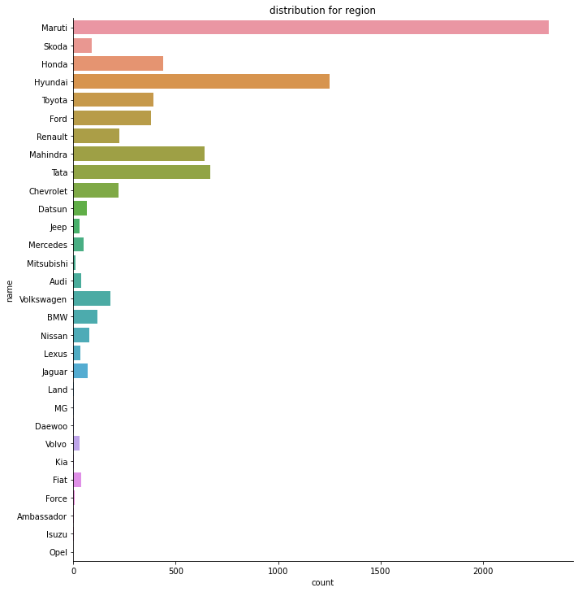

```python
#plotting the distribution for name
sns.catplot(data = car, y='name',kind='count',height= 10)
plt.title('distribution for region');
```

#### Observation

The car with the highest appearance is `Maruti` followed by Hyundai, Tata, Mahindra and Honda

### Discuss the distribution(s) of your variable(s) of interest. Were there any unusual points? Did you need to perform any transformations?

> Finally, the dataset reveals that most of the purchase cars where purchased between 2010 and 2020.

> No transformation was done on the dataset in relation to the key features. Although, some selling price values were above the upper limits, these values were significantly high in number and could affect the integrity of the data if deleted.

### Of the features you investigated, were there any unusual distributions? Did you perform any operations on the data to tidy, adjust, or change the form of the data? If so, why did you do this?

> The cleaning of the data set was done before the distribution of the variables were plotted.

> Changing of the abbreviated data such as LPG to liquified petroleum gas in the fuel column, and Y to yes in the sold column. This was done in order to make the data easier to read.

> Null values were also removed as these values would make the data unfit for analysis

> Values of `0` were removed as it was not possible for a car to have some technical properties as `0`; for instance, the presence of `0` in the mileage column.

> The seat column had data values in digits to represent the number of seats, however these values are categorical in nature hence it was best to change them to stringed and spelt terms.

> Other major quality issues were cleaned, for instance, the changing of columns' datatypes, this was in order to make it easy to assess and analyze the data/column